# Homework_advanced_vis

AB

2024-11-24

# Задание 1

```r
very_low_birthweight <- readRDS("Data/Raw/very_low_birthweight.RDS")

very_low_birthweight <- very_low_birthweight %>%
  mutate_if(is.integer, as.numeric) %>%
  mutate_at(vars(twn, magsulf, meth, toc, vent, pneumo, pda, cld, dead), as.factor)

filter_column_by_na_count <- function (df,na_threshold = 100) {
  na_count <- colSums(is.na(df))
  cols_to_remove <- names(na_count[na_count > na_threshold])
  if (length(cols_to_remove) > 0) {
    df <- df[, !(names(df) %in% cols_to_remove)]
    cat("Удалены столбцы:", cols_to_remove, "n")
  } else {
    cat("Столбцов с более чем", na_threshold, "NA не найдено.n")
  }
  return(df)
}

very_low_birthweight_nona <- filter_column_by_na_count (very_low_birthweight) %>%
na.omit(very_low_birthweight_nona)
```

```
## Удалены столбцы: lol magsulf meth toc pvh ivh ipe n
```

```r
write_rds(very_low_birthweight_nona, "Data/Raw/very_low_birthweight_nona.RDS")
```

# Задание 2 Постройте графики плотности распределения для числовых переменных. Удалите выбросы, если таковые имеются. Преобразуйте категориальные переменные в факторы. Для любых двух числовых переменных раскрасьте график по переменной ‘inout’.

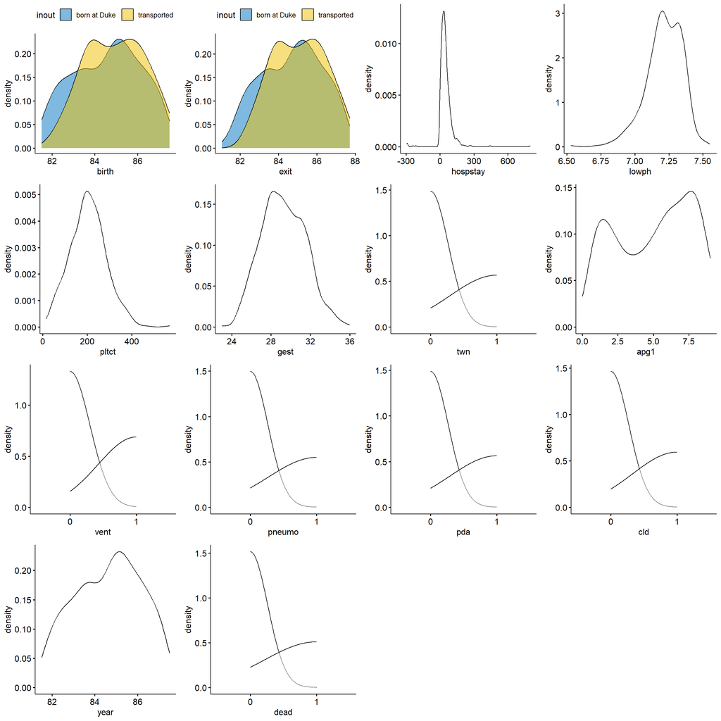

```r
birthdens <- ggdensity(very_low_birthweight_nona, x = "birth", fill = "inout", palette = "jco")

exitdens<- ggdensity(very_low_birthweight_nona, x = "exit", fill = "inout", palette = "jco")

hospstaydens<- ggdensity(very_low_birthweight_nona, x = "hospstay", palette = "jco")

lowphdens<- ggdensity(very_low_birthweight_nona, x = "lowph", palette = "jco")

pltctdens<- ggdensity(very_low_birthweight_nona, x = "pltct", palette = "jco")

gestdens<- ggdensity(very_low_birthweight_nona, x = "gest", palette = "jco")

twndens<- ggdensity(very_low_birthweight_nona, x = "twn", palette = "jco")

apg1dens<- ggdensity(very_low_birthweight_nona, x = "apg1", palette = "jco")

ventdens<- ggdensity(very_low_birthweight_nona, x = "vent", palette = "jco")

pneumodens<- ggdensity(very_low_birthweight_nona, x = "pneumo", palette = "jco")

pdadens<- ggdensity(very_low_birthweight_nona, x = "pda", palette = "jco")

clddens<- ggdensity(very_low_birthweight_nona, x = "cld", palette = "jco")

yeardens<- ggdensity(very_low_birthweight_nona, x = "year", palette = "jco")

deaddens<- ggdensity(very_low_birthweight_nona, x = "dead", palette = "jco")

ggarrange(birthdens, exitdens, hospstaydens, lowphdens, pltctdens, gestdens, twndens, apg1dens, ventdens, pneumodens, pdadens, clddens, yeardens, deaddens,
          ncol = 4, nrow = 4)
```

```r
summary(very_low_birthweight_nona)
```

```
##      birth            exit          hospstay           lowph
##  Min.   :81.51   Min.   :81.05   Min.   :-295.00   Min.   :6.530
##  1st Qu.:83.43   1st Qu.:83.56   1st Qu.:  21.00   1st Qu.:7.135
##  Median :84.77   Median :84.87   Median :  40.00   Median :7.220
##  Mean   :84.63   Mean   :84.76   Mean   :  47.04   Mean   :7.215
##  3rd Qu.:85.83   3rd Qu.:85.99   3rd Qu.:  64.00   3rd Qu.:7.320
##  Max.   :87.48   Max.   :87.72   Max.   : 797.00   Max.   :7.550
##      pltct                    race          bwt            gest
##  Min.   : 16.0   black          :303   Min.   : 400   Min.   :23.00
##  1st Qu.:148.0   native American: 13   1st Qu.: 960   1st Qu.:28.00
##  Median :204.0   oriental       :  4   Median :1160   Median :29.00
##  Mean   :204.5   white          :211   Mean   :1136   Mean   :29.25
##  3rd Qu.:256.0                         3rd Qu.:1330   3rd Qu.:31.00
##  Max.   :571.0                         Max.   :1500   Max.   :36.00
##           inout     twn          delivery        apg1       vent    pneumo
##  born at Duke:448   0:422   abdominal:262   Min.   :0.000   0:243   0:438
##  transported : 83   1:109   vaginal  :269   1st Qu.:2.000   1:288   1: 93
##                                             Median :5.000
##                                             Mean   :5.024
##                                             3rd Qu.:7.000
##                                             Max.   :9.000
##  pda     cld          year           sex      dead
##  0:425   0:393   Min.   :81.51   female:264   0:467
##  1:106   1:138   1st Qu.:83.43   male  :267   1: 64
##                  Median :84.77
##                  Mean   :84.63
##                  3rd Qu.:85.83
##                  Max.   :87.48
```

```r
replace_outliers_with_na <- function(df, method = "iqr", multiplier = 1.5) {

  if (!is.data.frame(df)) {
    stop("Input must be a data.frame.")
  }

  numeric_cols <- sapply(df, is.numeric)
  if (!any(numeric_cols)) {
    cat("No numeric columns found.n")
    return(df) # Возвращаем исходный датафрейм без изменений
  }

  for (col_name in names(df)[numeric_cols]) {
    if (method == "iqr") {
      Q1 <- quantile(df[[col_name]], 0.25, na.rm = TRUE)
      Q3 <- quantile(df[[col_name]], 0.75, na.rm = TRUE)
      IQR <- Q3 - Q1
      lower_bound <- Q1 - multiplier * IQR
      upper_bound <- Q3 + multiplier * IQR
      df[[col_name]][df[[col_name]] < lower_bound | df[[col_name]] > upper_bound] <- NA
    } else if (method == "sd") {
      mean_val <- mean(df[[col_name]], na.rm = TRUE)
      sd_val <- sd(df[[col_name]], na.rm = TRUE)
      lower_bound <- mean_val - multiplier * sd_val
      upper_bound <- mean_val + multiplier * sd_val
      df[[col_name]][df[[col_name]] < lower_bound | df[[col_name]] > upper_bound] <- NA
    } else {
      stop("Invalid method specified. Choose 'iqr' or 'sd'.")
    }
  }

    cat("Выбросы заменены на NA в столбцах:", names(df)[numeric_cols], "n")

  return(df)
}

very_low_birthweight_nona_iqr <- replace_outliers_with_na(very_low_birthweight_nona) %>%
  na.omit(very_low_birthweight_nona) %>%
  mutate(ID = row_number())
```

```
## Выбросы заменены на NA в столбцах: birth exit hospstay lowph pltct bwt gest apg1 year n
```

# Задание 3 Проведите тест на сравнение значений колонки ‘lowph’ между группами в переменной inout. Вид статистического теста определите самостоятельно. Визуализируйте результат через библиотеку ‘rstatix’. Как бы вы интерпретировали результат, если бы знали, что более низкое значение lowph ассоциировано с более низкой выживаемостью?

```r
compare_means(lowph ~ inout, data = very_low_birthweight_nona_iqr, method = "t.test")
```

```
## # A tibble: 1 × 8
##   .y.   group1       group2                p      p.adj p.format p.signif method
##   <chr> <chr>        <chr>             <dbl>      <dbl> <chr>    <chr>    <chr>
## 1 lowph born at Duke transported 0.000000560 0.00000056 5.6e-07  ****     T-test
```

# Задание 4 Сделайте новый датафрейм, в котором оставьте только континуальные или ранговые данные, кроме ‘birth’, ‘year’ и ‘exit’. Сделайте корреляционный анализ этих данных. Постройте два любых типа графиков для визуализации корреляций.

```r
very_low_birthweight_selected <- very_low_birthweight_nona_iqr %>%
  select(where(is.numeric), -birth, -year, -exit, -ID)

str (very_low_birthweight_selected)
```

```
## 'data.frame':    488 obs. of  6 variables:
##  $ hospstay: num  9 40 2 32 28 38 62 69 1 93 ...
##  $ lowph   : num  7.25 7.25 6.97 7.32 7.16 ...
##  $ pltct   : num  244 182 54 282 153 229 182 361 378 255 ...
##  $ bwt     : num  1370 1480 925 1255 1350 ...
##  $ gest    : num  32 32 28 29.5 34 32 28 28 28 26 ...
##  $ apg1    : num  7 8 5 9 4 6 6 6 2 4 ...
##  - attr(*, "na.action")= 'omit' Named int [1:43] 19 23 28 46 49 51 74 80 104 114 ...
##   ..- attr(*, "names")= chr [1:43] "28" "32" "42" "67" ...
```

```r
summary(very_low_birthweight_selected)
```

```
##     hospstay          lowph           pltct            bwt
##  Min.   : -2.00   Min.   :6.890   Min.   : 16.0   Min.   : 500
##  1st Qu.: 21.00   1st Qu.:7.140   1st Qu.:154.8   1st Qu.: 990
##  Median : 39.00   Median :7.230   Median :206.0   Median :1180
##  Mean   : 43.00   Mean   :7.224   Mean   :206.7   Mean   :1154
##  3rd Qu.: 60.25   3rd Qu.:7.320   3rd Qu.:256.0   3rd Qu.:1340
##  Max.   :124.00   Max.   :7.550   Max.   :418.0   Max.   :1500
##       gest            apg1
##  Min.   :25.00   Min.   :0.000
##  1st Qu.:28.00   1st Qu.:3.000
##  Median :29.00   Median :6.000
##  Mean   :29.39   Mean   :5.141
##  3rd Qu.:31.00   3rd Qu.:7.250
##  Max.   :35.00   Max.   :9.000
```

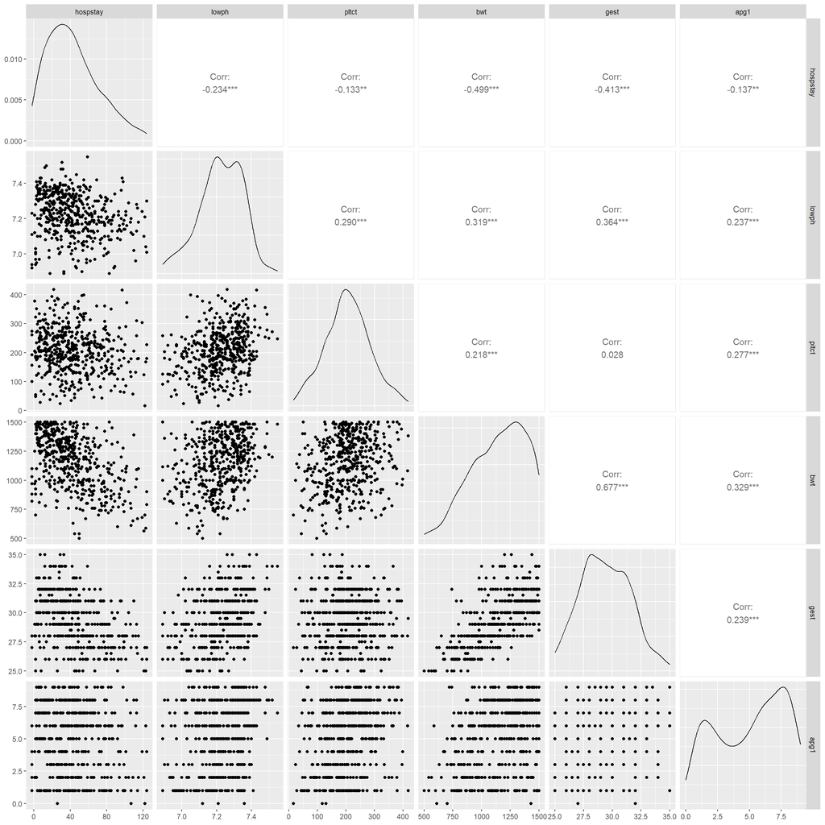

```r
vlbcor <- cor(very_low_birthweight_selected)

ggpairs(very_low_birthweight_selected)
```

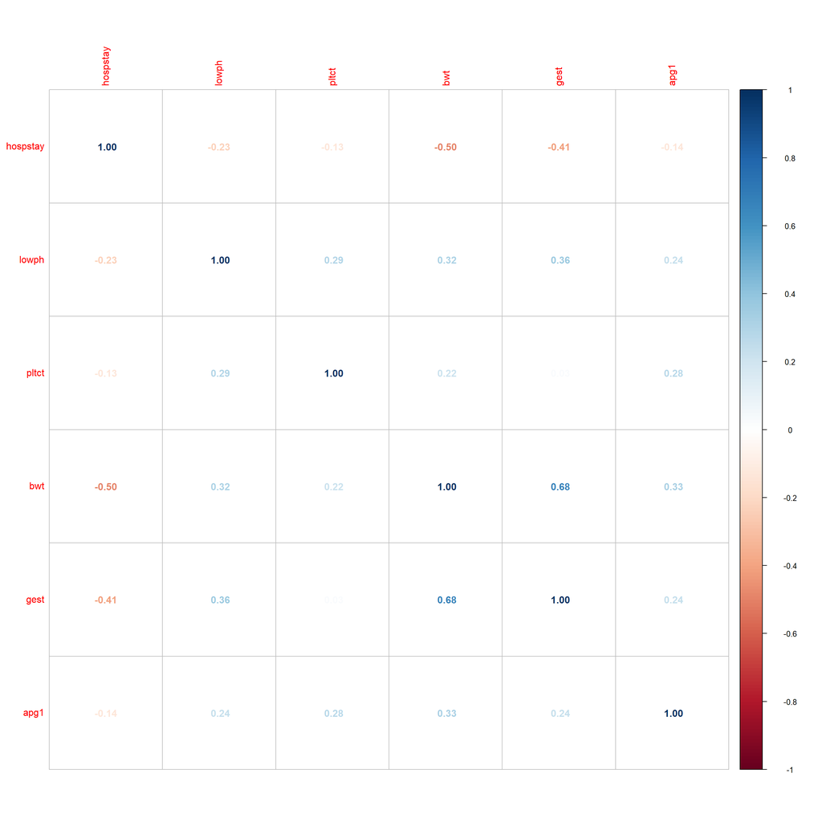

```r
corrplot(vlbcor, method = 'number')
```

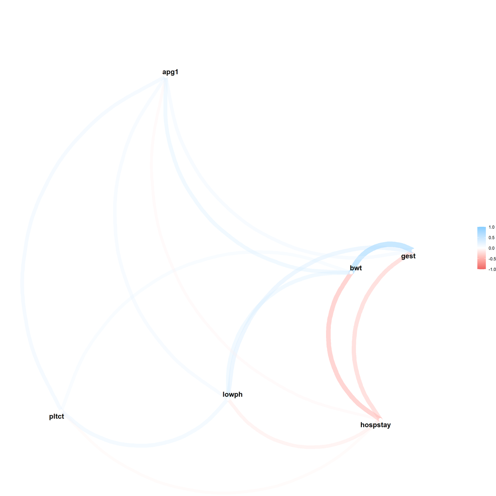

```r
vlbcor %>%
  network_plot(min_cor = .0)
```

# Задание 5 Постройте иерархическую кластеризацию на этом датафрейме.

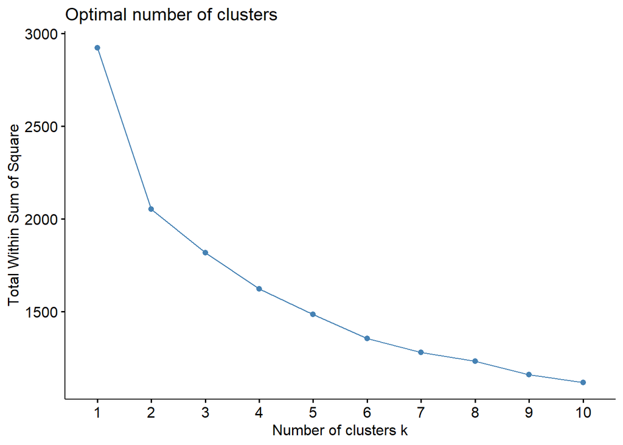

```r
very_low_birthweight_selected_scaled <- scale(very_low_birthweight_selected)

very_low_birthweight_selected_dist <- dist(very_low_birthweight_selected_scaled, method = "euclidean")

very_low_birthweight_selected_dist.hc <- hclust(d = very_low_birthweight_selected_dist,
                     method = "ward.D2")

fviz_nbclust(very_low_birthweight_selected_scaled, kmeans, method = "wss")
```

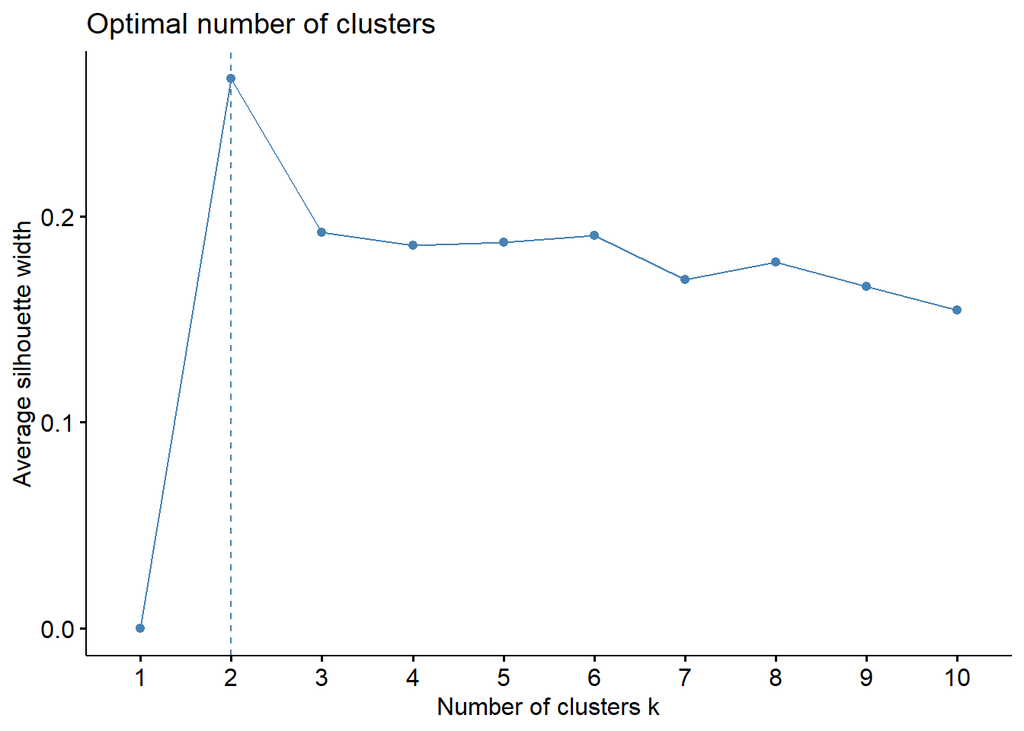

```r
fviz_nbclust(very_low_birthweight_selected_scaled, kmeans, method = "silhouette")
```

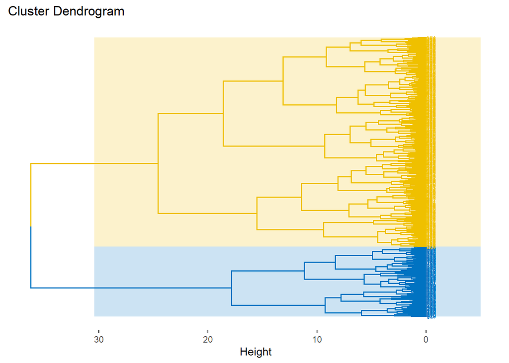

```r
fviz_dend(very_low_birthweight_selected_dist.hc,
          k = 2,
          cex = 0.4,
          horiz = TRUE,
          k_colors = "jco",
          rect = TRUE,
          rect_border = "jco",
          rect_fill = TRUE)
```

# Задание 6 Сделайте одновременный график heatmap и иерархической кластеризации. Интерпретируйте результат.

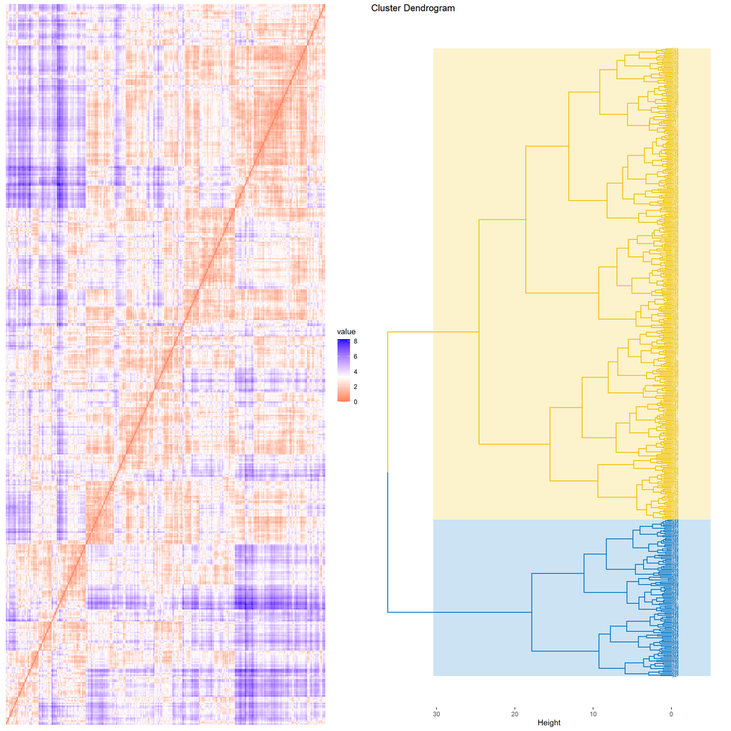

```r
heat <- fviz_dist(very_low_birthweight_selected_dist, show_labels = FALSE)

dendro <- fviz_dend(very_low_birthweight_selected_dist.hc,
          k = 2,
          cex = 0.4,
          horiz = TRUE,
          k_colors = "jco",
          rect = TRUE,
          rect_border = "jco",
          rect_fill = TRUE)

ggarrange(heat, dendro,
          ncol = 2, nrow = 1)
```

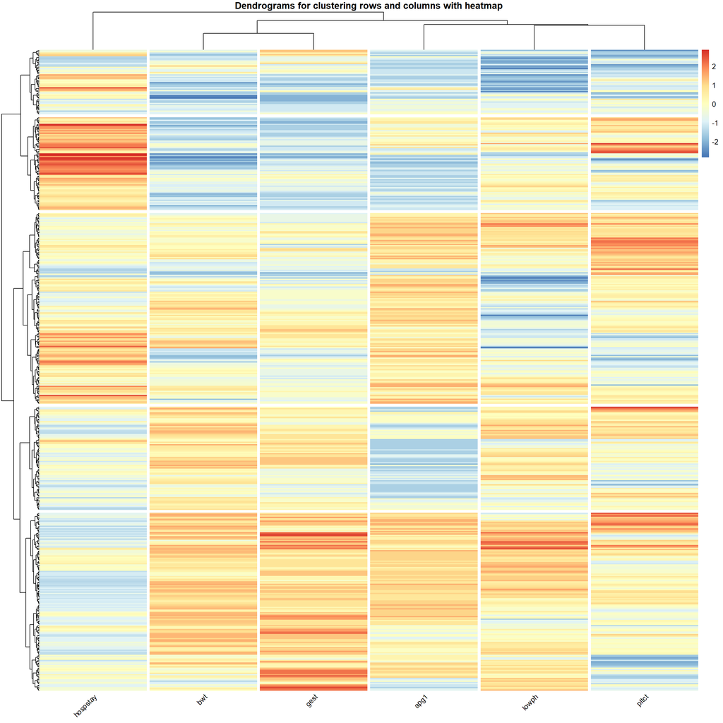

```r
pheatmap(very_low_birthweight_selected_scaled,
         show_rownames = FALSE,
         clustering_distance_rows = very_low_birthweight_selected_dist,
         clustering_method = "ward.D2",
         cutree_rows = 5,
         cutree_cols = length(colnames(very_low_birthweight_selected_scaled)),
         angle_col = 45,
         main = "Dendrograms for clustering rows and columns with heatmap")
```

Интерпретация: на heatmap выделяются группы синих строк, что свидетельствует о наличии схожих наблюдений. В результате использования двух методов подсчета возможного количества кластеров, выяснилось, что вероятнее всего их два. Дендрограмма постоенная на основе имеющихся данных поделена на 2 кластера.

# Задание 7

Проведите PCA анализ на этих данных. Проинтерпретируйте результат. Нужно ли применять шкалирование для этих данных перед проведением PCA?

```r
very_low_birthweight.pca <- prcomp(very_low_birthweight_selected,
                scale = T)
summary(very_low_birthweight.pca)
```

```
## Importance of components:
##                           PC1    PC2    PC3    PC4     PC5     PC6
## Standard deviation     1.5954 1.0661 0.8823 0.8512 0.73334 0.52677
## Proportion of Variance 0.4242 0.1894 0.1298 0.1208 0.08963 0.04625
## Cumulative Proportion  0.4242 0.6136 0.7434 0.8641 0.95375 1.00000
```

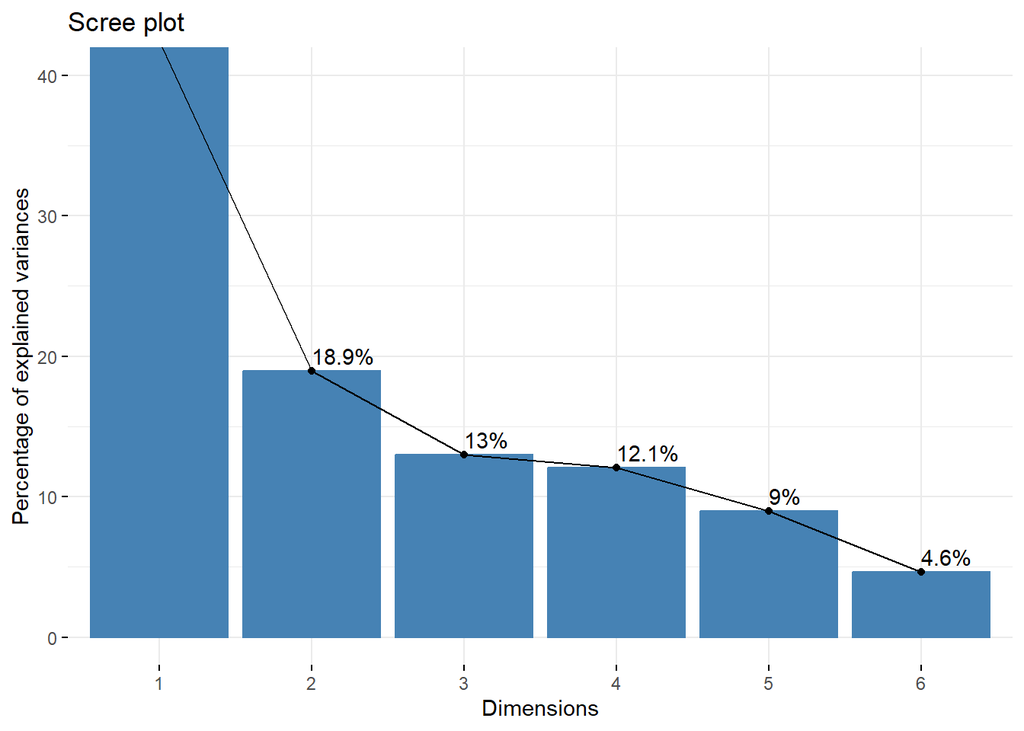

```r
fviz_eig(very_low_birthweight.pca, addlabels = T, ylim = c(0, 40))
```

Шкалирование необходимо, так как переменные измеряются в разных единицах, что будет вносить вклад в расчет дисперсий и определение главных компонент, а соответсвенно к неверным результатам.

Интерпретация: в наших данных первыми двумя компонетами объясняется 61% вариации, что говорит о том, что в данных много скоррелированных переменных и pca начинает вбирать в себя корреляцию. PC1 имеет наибольшее стандартное отклонение (1.5954), что означает, что она объясняет наибольшую вариабельность в данных. PC1 объясняет 42.42% общей дисперсии, PC2 - 18.94%.В данном случае, можно рассмотреть использование первых четырех компонент (PC1-PC4), которые вместе объясняют 86.41% дисперсии.

# Задание 8

Постройте biplot график для PCA. Раскрасьте его по значению колонки ‘dead’.

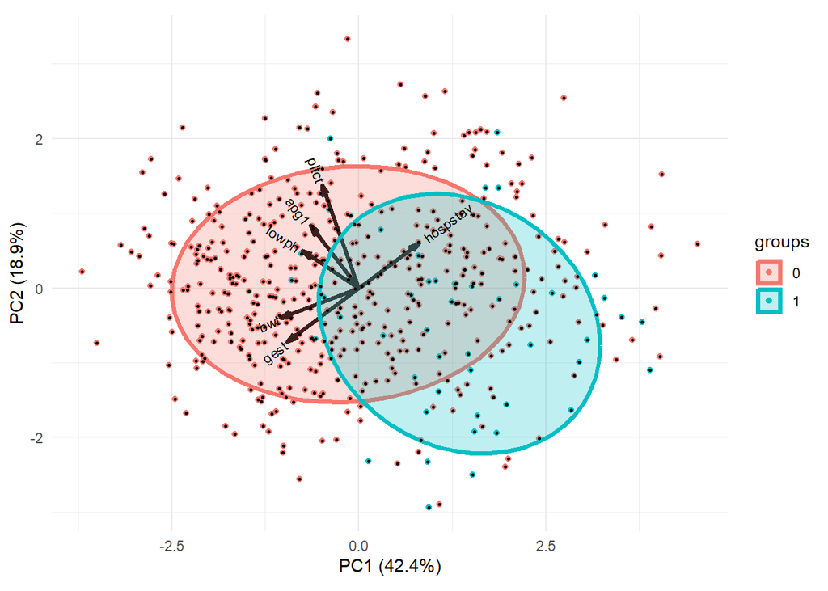

```r
very_low_birthweight_biplot <-
  ggbiplot(very_low_birthweight.pca,
         scale=0,
         groups = as.factor(very_low_birthweight_nona_iqr$dead),
         ellipse = T)+
  theme_minimal() +
  geom_point(aes(text = paste("ID:", very_low_birthweight_nona_iqr$ID)),
             size = 0.5)
very_low_birthweight_biplot
```

# Задание 9

Переведите последний график в ‘plotly’. При наведении на точку нужно, чтобы отображалось id пациента.

```r
very_low_birthweight_plotly <- ggplotly(very_low_birthweight_biplot, tooltip = "text")
very_low_birthweight_plotly
```

[interactive chart not shown]

# Задание 10

Дайте содержательную интерпретацию PCA анализу. Почему использовать колонку ‘dead’ для выводов об ассоциации с выживаемостью некорректно?

Согласно PCA анализу есть 6 главных компонент, которые описывают вариативность исходных данных. В наших данных первыми двумя компонетами объясняется 61% вариации, что говорит о том, что в данных много скоррелированных переменных. PC1 имеет наибольшее стандартное отклонение (1.5954), что означает, что она объясняет наибольшую вариабельность в данных, она объясняет 42.42% общей дисперсии. Таким образом, есть один основной фактор, влияющий на большую часть вариации данных. PC2 объясняет 18.94%, таким образом вероятно существует второй фактор. Использование первых четырех компонент (PC1-PC4), которые вместе объясняют 86.41% дисперсии могут быть достаточными для анализа.

Колонка dead является плохим вариантом для формирования выводов об ассоциации с выживаемостью, так как формирующиеся группы сильно перекрываются, соответственно плохо разделяются в пространстве главных компонент.

# Задание 11

Приведите ваши данные к размерности в две колонки через UMAP. Сравните результаты отображения точек между алгоритмами PCA и UMAP.

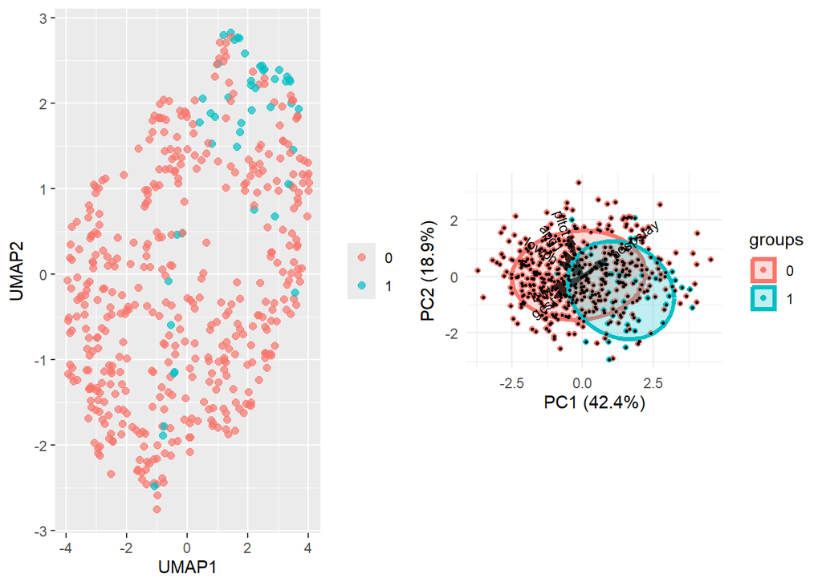

```r
umap_prep <- recipe(~., data = very_low_birthweight_selected) %>%
  step_normalize(all_predictors()) %>%
  step_umap(all_predictors()) %>%
  prep() %>%
  juice()

umap_graph <- umap_prep %>%
  ggplot(aes(UMAP1, UMAP2)) +
  geom_point(aes(color = as.factor(very_low_birthweight_nona_iqr$dead)),
             alpha = 0.7, size = 2)+
  labs(color = NULL)

ggarrange(umap_graph, very_low_birthweight_biplot,
          ncol = 2, nrow = 1)
```

Отображение точек изменилось в сторону сгущения: точки, относящие к одной группы более плотно прилежат друг к другу, однако все равно активно перекрываются, как на предыдущем графике

# Задание 12 Давайте самостоятельно увидим, что снижение размерности – это группа методов, славящаяся своей неустойчивостью. Измените основные параметры UMAP (n_neighbors и min_dist) и проанализируйте, как это влияет на результаты.

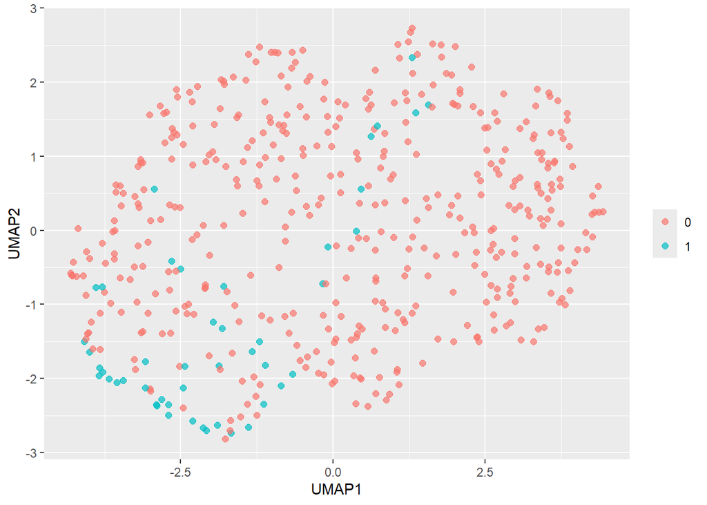

```r
umap_prep_dist0.1 <- recipe(~., data = very_low_birthweight_selected) %>%
  step_normalize(all_predictors()) %>%
  step_umap( min_dist = 0.1, all_predictors()) %>%
  prep() %>%
  juice()

umap_prep_dist0.1 %>%
  ggplot(aes(UMAP1, UMAP2)) +
  geom_point(aes(color = as.factor(very_low_birthweight_nona_iqr$dead)),
             alpha = 0.7, size = 2)+
  labs(color = NULL)
```

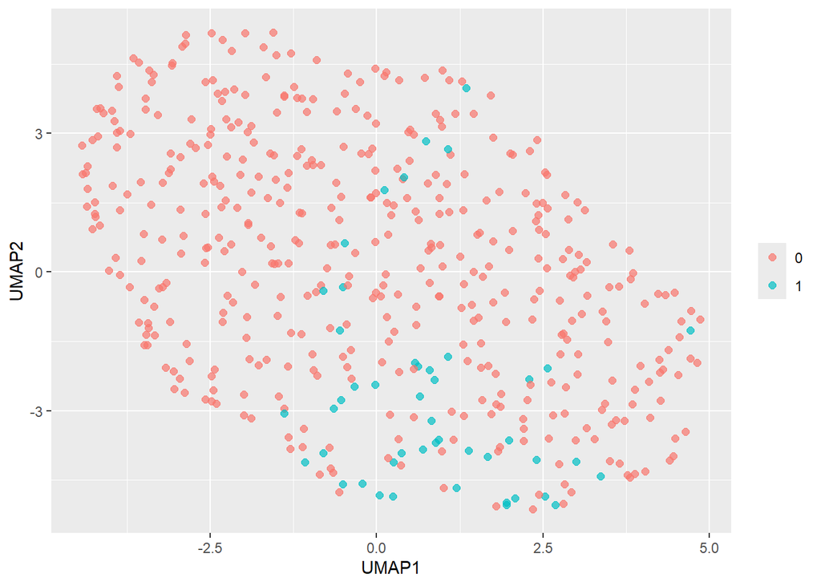

```r
umap_prep_dist0.5 <- recipe(~., data = very_low_birthweight_selected) %>%
  step_normalize(all_predictors()) %>%
  step_umap(min_dist = 0.5, all_predictors()) %>%
  prep() %>%
  juice()

umap_prep_dist0.5 %>%
  ggplot(aes(UMAP1, UMAP2)) +
  geom_point(aes(color = as.factor(very_low_birthweight_nona_iqr$dead)),
             alpha = 0.7, size = 2)+
  labs(color = NULL)
```

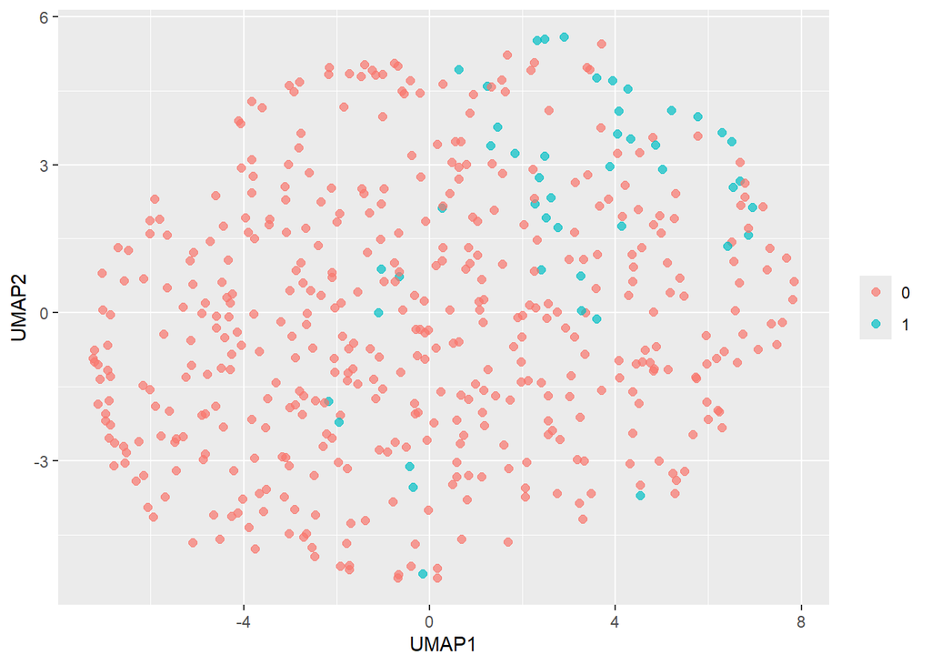

```r
umap_prep_dist0.99 <- recipe(~., data = very_low_birthweight_selected) %>%
  step_normalize(all_predictors()) %>%
  step_umap(min_dist = 0.99, all_predictors()) %>%
  prep() %>%
  juice()

umap_prep_dist0.99 %>%
  ggplot(aes(UMAP1, UMAP2)) +
  geom_point(aes(color = as.factor(very_low_birthweight_nona_iqr$dead)),
             alpha = 0.7, size = 2)+
  labs(color = NULL)
```

Параметр min_dist в UMAP контролирует, насколько близко точки могут располагаться друг к другу на результирующем графике. Малое значение min_dist (например, 0.1) позволяет алгоритму отобразить мелкие детали и локальные структуры, такие как небольшие кластеры и цепочки точек. Увеличение min_dist приводит к размытию этих деталей и выделению более общих черт данных. При этом теряется информация о локальной топологии, но становится более заметна глобальная структура.

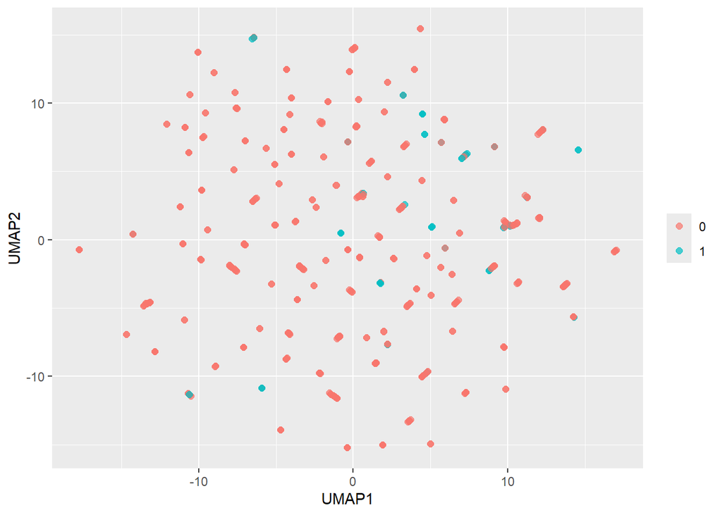

```r
umap_prep_neighbors2 <- recipe(~., data = very_low_birthweight_selected) %>%
  step_normalize(all_predictors()) %>%
  step_umap(neighbors = 2, all_predictors()) %>%
  prep() %>%
  juice()

umap_prep_neighbors2 %>%
  ggplot(aes(UMAP1, UMAP2)) +
  geom_point(aes(color = as.factor(very_low_birthweight_nona_iqr$dead)),
             alpha = 0.7, size = 2)+
  labs(color = NULL)
```

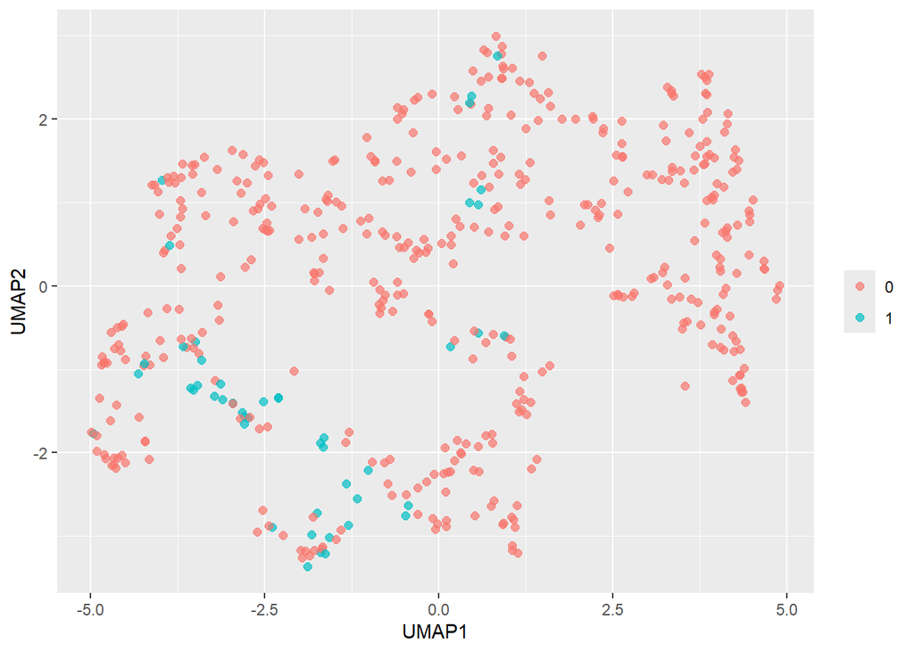

```r
umap_prep_neighbors8 <- recipe(~., data = very_low_birthweight_selected) %>%
  step_normalize(all_predictors()) %>%
  step_umap(neighbors = 8, all_predictors()) %>%
  prep() %>%
  juice()

umap_prep_neighbors8 %>%
  ggplot(aes(UMAP1, UMAP2)) +
  geom_point(aes(color = as.factor(very_low_birthweight_nona_iqr$dead)),
             alpha = 0.7, size = 2)+
  labs(color = NULL)
```

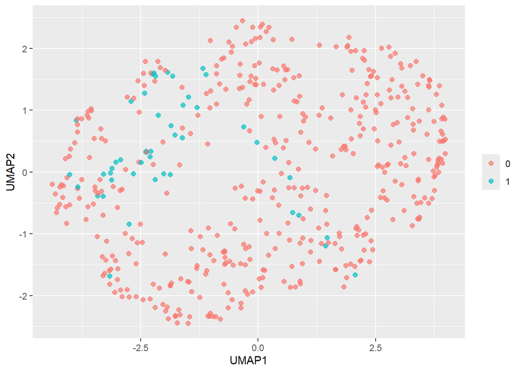

```r
umap_prep_neighbors15 <- recipe(~., data = very_low_birthweight_selected) %>%
  step_normalize(all_predictors()) %>%
  step_umap(neighbors = 15, all_predictors()) %>%
  prep() %>%
  juice()

umap_prep_neighbors15 %>%
  ggplot(aes(UMAP1, UMAP2)) +
  geom_point(aes(color = as.factor(very_low_birthweight_nona_iqr$dead)),
             alpha = 0.7, size = 2)+
  labs(color = NULL)
```

При малом значении n_neighbors (2) UMAP отображает только локальные связи, формируя разрозненные компоненты. С увеличением n_neighbors (8) алгоритм учитывает более глобальную структуру, объединяя компоненты и лучше отражая взаимосвязи между ними. При большом значенииn_neighbors (15) график демонстрирует преимущественно общую структуру данных.